# PROJECT MPDW P2 KELOMPOK 8

## Library

```r
library(ggplot2)
library(tsibble)
library(tseries)
library(MASS)
library(forecast)
library(TSA)
library(TTR)
library(aTSA)
library(graphics)
library(readxl)
library(fGarch)
library(FinTS)
library(rugarch)
```

# SUMBER DATA

Topik : Pariwisata  
Data : Penumpang Tiba Internasional dari sebnyak 731 Periode (1 Januari 2022-1 Januari 2024)  
Sumber : SIASATI | SISTEM INFORMASI ANGKUTAN DAN SARANA TRANSPORTASI INDONESIA, Kementerian Perhubungan

# ARIMA

## Input Data

```r
mpdw <- read_xlsx("C:/Users/Ghonniyu/Downloads/MPDW - Copy.xlsx")
Penumpang <- mpdw$Penumpang
DataP <- ts(Penumpang)
class(DataP)
```

```
## [1] "ts"
```

## Eksplorasi Data

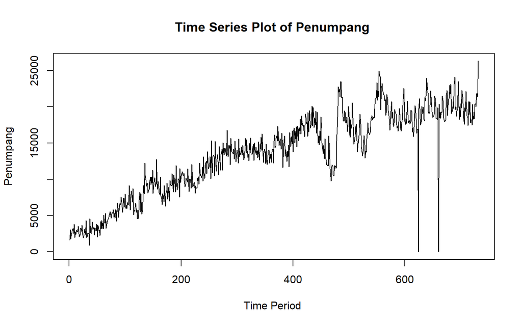

```r
ts.plot(DataP, xlab="Time Period ", ylab="Penumpang", main= "Time Series Plot of Penumpang ")
```

### Interpolasi data

```r
library(imputeTS)
# Mengganti nilai 0 dengan NA untuk memungkinkan interpolasi
DataP[DataP == 0] <- NA

# Interpolasi linier pada data time series
DataP_spline <- na_interpolation(DataP, option = "spline")
```

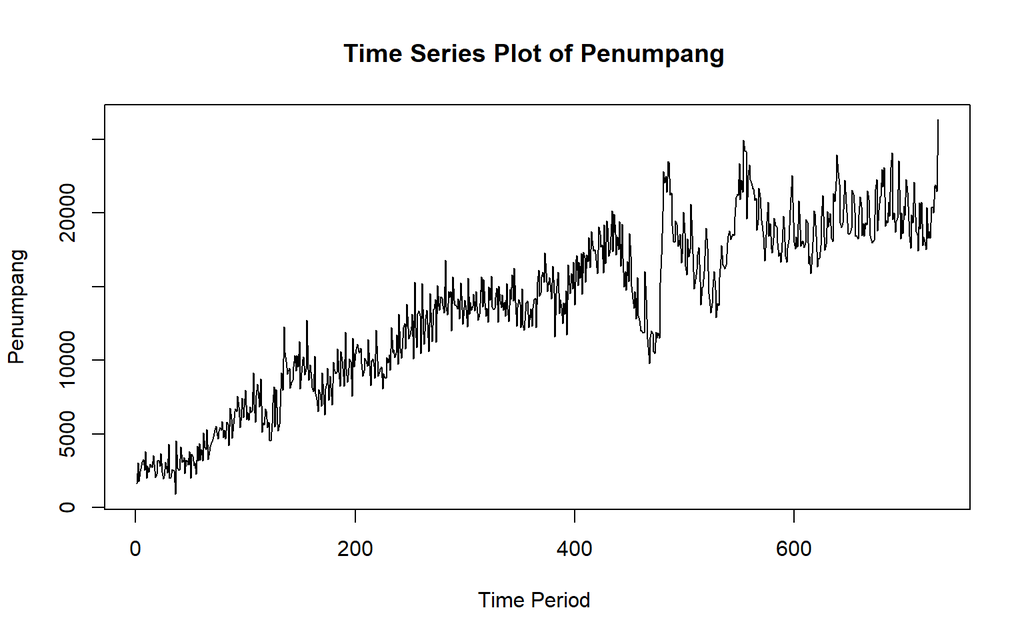

```r
ts.plot(DataP_spline, xlab="Time Period ", ylab="Penumpang", main= "Time Series Plot of Penumpang ")
```

### Data Latih

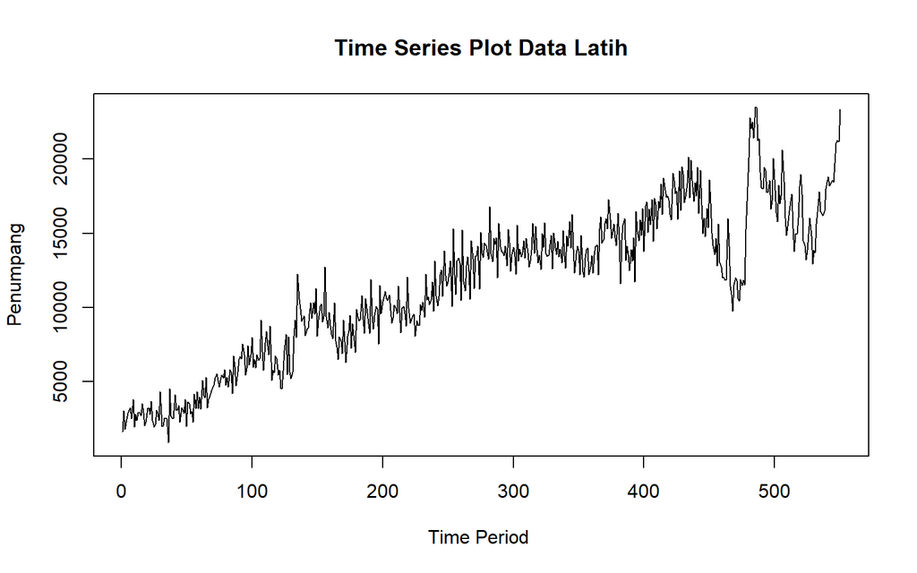

```r
TrainP <- DataP_spline[1:550] |> ts()
ts.plot(TrainP, xlab="Time Period ", ylab="Penumpang", main= "Time Series Plot Data Latih")
```

### Data Uji

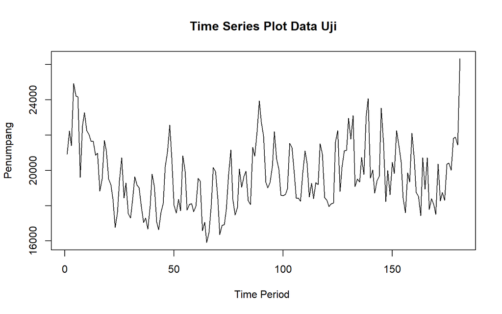

```r
TestP <- DataP_spline[551:731] |> ts()
ts.plot(TestP, xlab="Time Period ", ylab="Penumpang", main= "Time Series Plot Data Uji")
```

## Uji Stasioneritas Data

### Stasioner dalam Rataan

#### Plot ACF

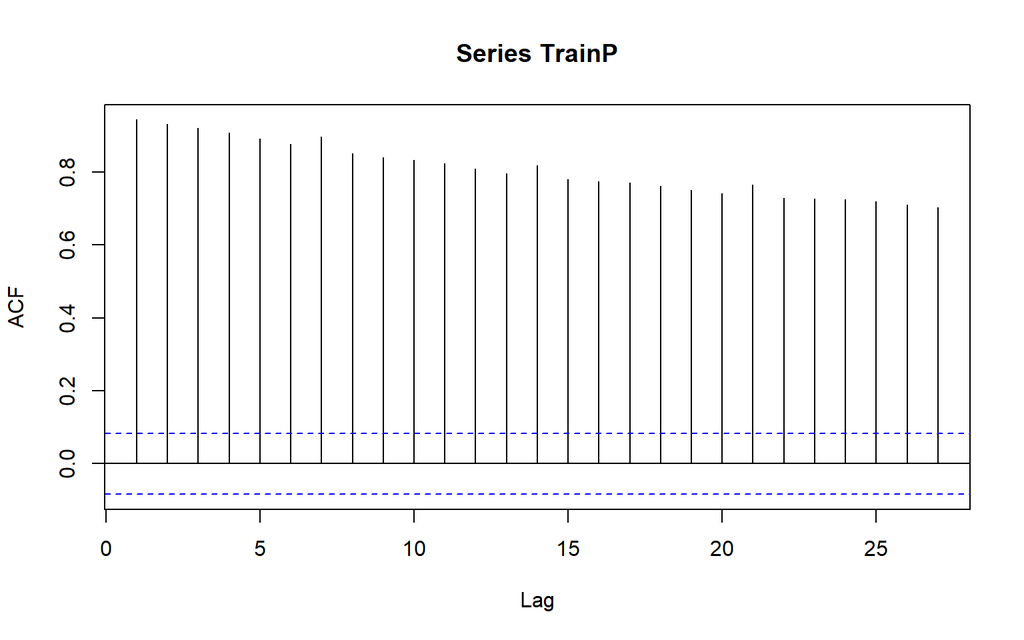

```r
acf(TrainP)
```

Berdasarkan plot ACF, terlihat bahwa plot ACF tersebut tidak stasioner dalam rataan

#### Uji ADF

```r
tseries::adf.test(TrainP)
```

```
##
##  Augmented Dickey-Fuller Test
##
## data:  TrainP
## Dickey-Fuller = -4.8825, Lag order = 8, p-value = 0.01
## alternative hypothesis: stationary
```

$H_0$ : Data tidak stasioner dalam rataan

$H_1$ : Data stasioner dalam rataan

Berdasarkan uji ADF tersebut, didapat *p-value* sebesar 0.01 yang lebih kecil dari taraf nyata 5% sehingga tolak $H_0$ dan menandakan bahwa data stasioner dalam rataan. Hal ini berbeda dengan hasil eksplorasi menggunakan plot time series dan plot ACF, sehingga kami mengambil kesimpulan untuk mengikuti hasil eksplorasi. Ketidakstasioneran model kedepannya harus ditangani.

### Stasioneritas dalam Ragam

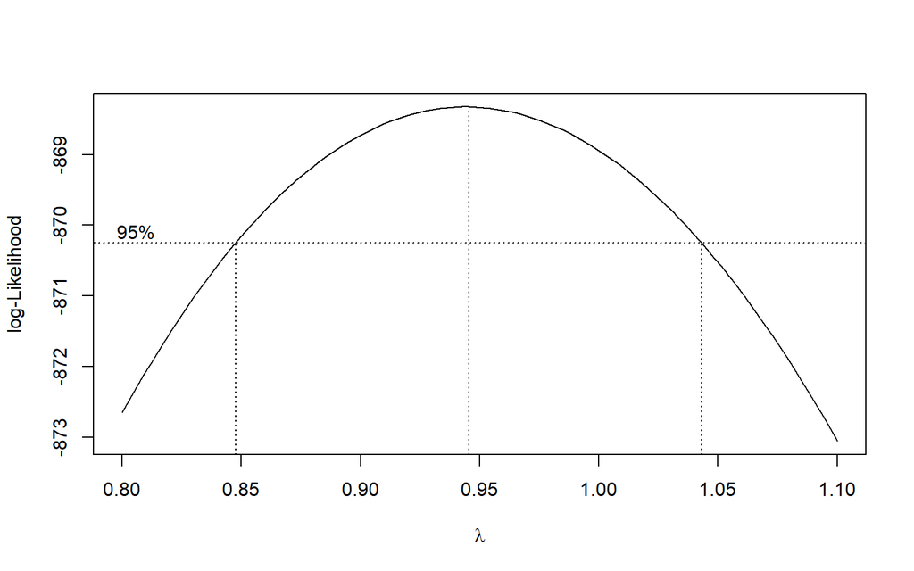

```r
index <- seq(1:550)
bc = boxcox(TrainP~index, lambda = seq(0.8,1.1,by=0.1))
```

```r
#Nilai Rounded Lambda
lambda <- bc$x[which.max(bc$y)]
lambda
```

```
## [1] 0.9454545
```

```r
#SK
bc$x[bc$y > max(bc$y) - 1/2 * qchisq(.95,1)]
```

```
##  [1] 0.8484848 0.8515152 0.8545455 0.8575758 0.8606061 0.8636364 0.8666667
##  [8] 0.8696970 0.8727273 0.8757576 0.8787879 0.8818182 0.8848485 0.8878788
## [15] 0.8909091 0.8939394 0.8969697 0.9000000 0.9030303 0.9060606 0.9090909
## [22] 0.9121212 0.9151515 0.9181818 0.9212121 0.9242424 0.9272727 0.9303030
## [29] 0.9333333 0.9363636 0.9393939 0.9424242 0.9454545 0.9484848 0.9515152
## [36] 0.9545455 0.9575758 0.9606061 0.9636364 0.9666667 0.9696970 0.9727273
## [43] 0.9757576 0.9787879 0.9818182 0.9848485 0.9878788 0.9909091 0.9939394
## [50] 0.9969697 1.0000000 1.0030303 1.0060606 1.0090909 1.0121212 1.0151515
## [57] 1.0181818 1.0212121 1.0242424 1.0272727 1.0303030 1.0333333 1.0363636
## [64] 1.0393939 1.0424242
```

## Penanganan Stasioneritas dalam Rataan

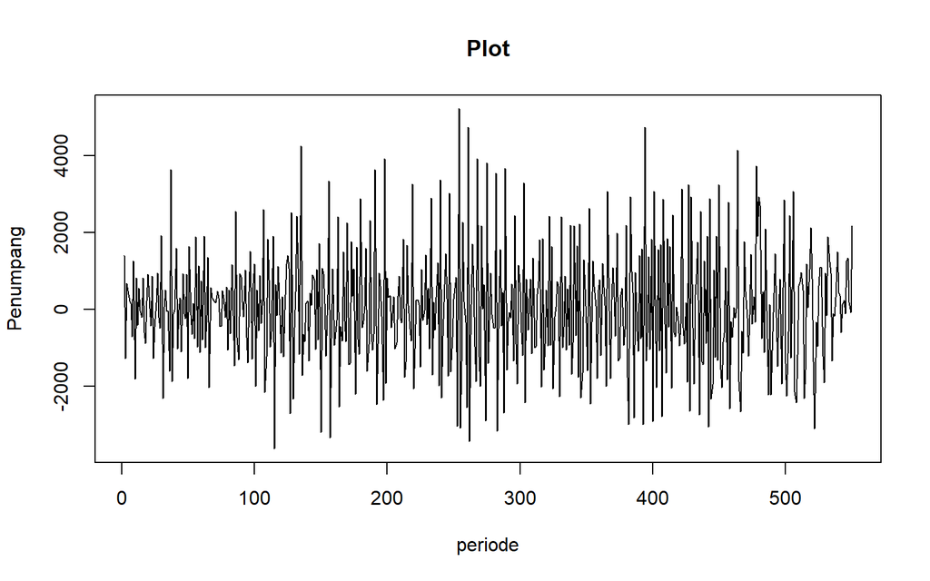

```r
train.diff<-diff(TrainP,differences = 1)
plot.ts(train.diff, lty=1, xlab="periode", ylab="Penumpang", main="Plot")
```

#### Plot ACF penanganan stationer dalam rataan

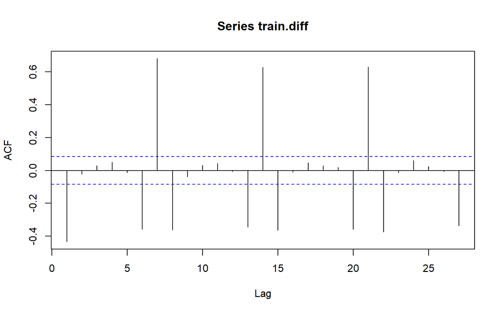

```r
acf(train.diff)
```

#### Uji ADF

```r
tseries::adf.test(train.diff)
```

```
##
##  Augmented Dickey-Fuller Test
##
## data:  train.diff
## Dickey-Fuller = -7.6249, Lag order = 8, p-value = 0.01
## alternative hypothesis: stationary
```

$H_0$ : Data tidak stasioner dalam rataan

$H_1$ : Data stasioner dalam rataan

Sesuai dengan uji adf melihat nilai p-value nya yaitu 0.01 yaitu kurang dari taraf nyata 5% sehingga data latih yang sudah di diff satu kali sudah stasioner dalam rataan. Didukung juga dengan plot acf dengan pola “cut off”

### Pendugaan Parameter Model Tentatif

#### Plot ACF

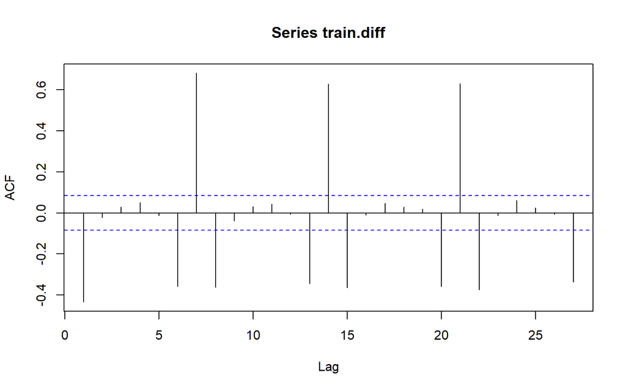

```r
acf(train.diff)
```

#### Plot PACF

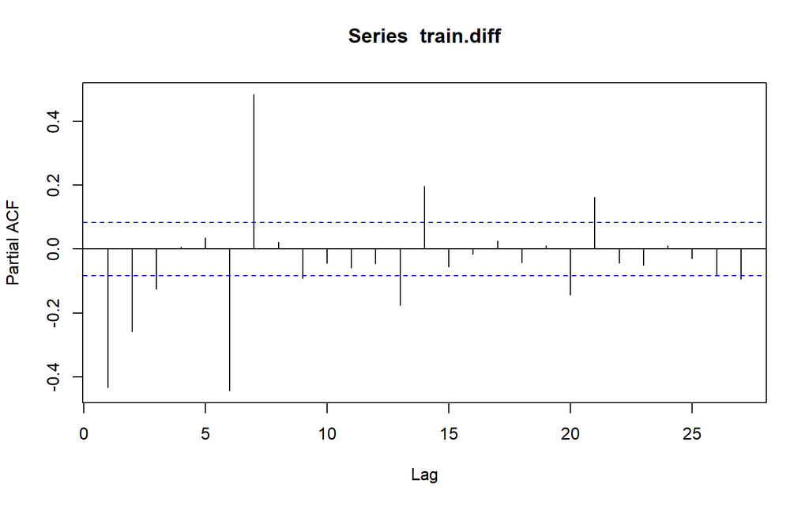

```r
pacf(train.diff)
```

Berdasarkan plot tersebut, terlihat bahwa plot PACF cenderung *tails off* pada lag ke 1, sehingga jika plot ACF dianggap *cut-off*, maka model tentatifnya adalah ARIMA(0,1,1).

#### Plot EACF

```r
eacf(train.diff)
```

```
## AR/MA
##   0 1 2 3 4 5 6 7 8 9 10 11 12 13
## 0 x o o o o x x x o o o  o  x  x
## 1 x x o o o x x x x o o  o  x  x
## 2 x x x o o o x x x x o  o  o  x
## 3 o x o o o o x x o o x  o  o  x
## 4 x o o o o o x x o o o  o  o  x
## 5 o o x x o o x o x x x  o  o  x
## 6 x x x x x o x x x x x  x  x  x
## 7 o x x x x o x o o o o  o  o  o
```

Identifikasi model menggunakan plot EACF dilakukan dengan melihat ujung segitiga pada pola segitiga nol. Dalam hal ini model tentatif yang dapat terbentuk adalah ARIMA(0,1,1), ARIMA(1,1,2), ARIMA (3,1,2), dan ARIMA (4,1,3)

### Pemilihan Parameter Model Tentatif

#### ARIMA(0,1,1)

```r
model1.da=Arima(train.diff, order=c(0,0,1),method="ML")
summary(model1.da)
```

```
## Series: train.diff
## ARIMA(0,0,1) with non-zero mean
##
## Coefficients:
##           ma1     mean
##       -0.5737  35.9680
## s.e.   0.0339  24.4507
##
## sigma^2 = 1803624:  log likelihood = -4732.45
## AIC=9470.9   AICc=9470.95   BIC=9483.83
##
## Training set error measures:
##                    ME     RMSE      MAE      MPE     MAPE      MASE        ACF1
## Training set 1.204432 1340.542 1040.031 61.17287 177.1321 0.5100348 -0.01222766
```

```r
lmtest::coeftest(model1.da)
```

```
##
## z test of coefficients:
##
##            Estimate Std. Error z value Pr(>|z|)
## ma1       -0.573715   0.033901 -16.924   <2e-16 ***
## intercept 35.967991  24.450739   1.471   0.1413
## ---
## Signif. codes:  0 '***' 0.001 '**' 0.01 '*' 0.05 '.' 0.1 ' ' 1
```

#### ARIMA(1,1,2)

```r
model2.da=Arima(train.diff, order=c(1,0,2),method="ML")
summary(model2.da)
```

```
## Series: train.diff
## ARIMA(1,0,2) with non-zero mean
##
## Coefficients:
```

```
##           ar1      ma1      ma2     mean
##       -0.2578  -0.3217  -0.1383  35.9880
## s.e.      NaN      NaN      NaN  24.6199
##
## sigma^2 = 1810064:  log likelihood = -4732.43
## AIC=9474.85   AICc=9474.96   BIC=9496.39
##
## Training set error measures:
##                    ME     RMSE      MAE      MPE     MAPE      MASE
## Training set 1.225941 1340.476 1040.585 61.49623 178.0953 0.5103067
##                      ACF1
## Training set -0.006815997
```

```r
lmtest::coeftest(model2.da)
```

```
##
## z test of coefficients:
##
##           Estimate Std. Error z value Pr(>|z|)
## ar1       -0.25782        NaN     NaN      NaN
## ma1       -0.32169        NaN     NaN      NaN
## ma2       -0.13834        NaN     NaN      NaN
## intercept 35.98802   24.61988  1.4617   0.1438
```

#### ARIMA(3,1,2)

```r
model3.da=Arima(train.diff, order=c(3,0,2),method="ML")
summary(model3.da)
```

```
## Series: train.diff
## ARIMA(3,0,2) with non-zero mean
##
## Coefficients:
```

```
##           ar1      ar2      ar3      ma1      ma2     mean
##       -0.2894  -0.1048  -0.0177  -0.2964  -0.0661  36.3462
## s.e.      NaN      NaN      NaN      NaN      NaN  25.8557
##
## sigma^2 = 1813066:  log likelihood = -4731.87
## AIC=9477.75   AICc=9477.95   BIC=9507.9
##
## Training set error measures:
##                   ME     RMSE      MAE      MPE     MAPE      MASE
## Training set 1.05482 1339.123 1040.975 61.85484 175.3437 0.5104979
##                       ACF1
## Training set -5.516913e-05
```

```r
lmtest::coeftest(model3.da)
```

```
##
## z test of coefficients:
##
##            Estimate Std. Error z value Pr(>|z|)
## ar1       -0.289401        NaN     NaN      NaN
## ar2       -0.104794        NaN     NaN      NaN
## ar3       -0.017732        NaN     NaN      NaN
## ma1       -0.296365        NaN     NaN      NaN
## ma2       -0.066129        NaN     NaN      NaN
## intercept 36.346154  25.855685  1.4057   0.1598
```

#### ARIMA(3,1,3)

```r
model4.da=Arima(train.diff, order=c(3,0,3),method="ML")
summary(model4.da)
```

```
## Series: train.diff
## ARIMA(3,0,3) with non-zero mean
##
## Coefficients:
```

```
##           ar1     ar2     ar3     ma1      ma2      ma3     mean
##       -1.0609  0.3269  0.7339  0.7992  -0.7325  -0.9162  30.2477
## s.e.      NaN     NaN     NaN     NaN      NaN      NaN   8.0503
##
## sigma^2 = 1495984:  log likelihood = -4680.2
## AIC=9376.41   AICc=9376.67   BIC=9410.87
##
## Training set error measures:
##                    ME     RMSE      MAE      MPE     MAPE      MASE        ACF1
## Training set 1.533334 1215.282 970.7672 54.76586 208.5398 0.4760677 -0.04422347
```

```r
lmtest::coeftest(model4.da)
```

```
##
## z test of coefficients:
##
##           Estimate Std. Error z value  Pr(>|z|)
## ar1       -1.06092        NaN     NaN       NaN
## ar2        0.32691        NaN     NaN       NaN
## ar3        0.73392        NaN     NaN       NaN
## ma1        0.79923        NaN     NaN       NaN
## ma2       -0.73250        NaN     NaN       NaN
## ma3       -0.91621        NaN     NaN       NaN
## intercept 30.24768    8.05028  3.7573 0.0001717 ***
## ---
## Signif. codes:  0 '***' 0.001 '**' 0.01 '*' 0.05 '.' 0.1 ' ' 1
```

#### ARIMA(4,1,3)

```r
model5.da=Arima(train.diff, order=c(4,0,3),method="ML")
summary(model5.da)
```

```
## Series: train.diff
## ARIMA(4,0,3) with non-zero mean
##
## Coefficients:
##           ar1      ar2     ar3     ar4      ma1     ma2      ma3     mean
##       -0.0135  -0.3549  0.6296  0.4481  -0.5548  0.5108  -0.9560  29.7935
## s.e.   0.0405   0.0290  0.0282  0.0399   0.0189  0.0236   0.0195   2.4572
##
## sigma^2 = 1389046:  log likelihood = -4660.6
## AIC=9339.2   AICc=9339.53   BIC=9377.97
##
## Training set error measures:
##                    ME     RMSE      MAE      MPE     MAPE      MASE      ACF1
## Training set 34.96306 1169.959 912.8146 18.60563 181.3444 0.4476475 0.0188068
```

```r
lmtest::coeftest(model5.da)
```

```
##
## z test of coefficients:
##
##            Estimate Std. Error  z value Pr(>|z|)
## ar1       -0.013521   0.040550  -0.3334   0.7388
## ar2       -0.354857   0.029024 -12.2264   <2e-16 ***
## ar3        0.629637   0.028183  22.3411   <2e-16 ***
## ar4        0.448142   0.039893  11.2336   <2e-16 ***
## ma1       -0.554776   0.018940 -29.2911   <2e-16 ***
## ma2        0.510806   0.023588  21.6555   <2e-16 ***
## ma3       -0.956020   0.019519 -48.9802   <2e-16 ***
## intercept 29.793459   2.457225  12.1248   <2e-16 ***
## ---
## Signif. codes:  0 '***' 0.001 '**' 0.01 '*' 0.05 '.' 0.1 ' ' 1
```

## Analisis Sisaan

Model terbaik hasil pendugaan parameter kemudian dilakukan cek asumsi sisaannya. Sisaan model ARIMA wajib memenuhi asumsi normalitas, kebebasan sisaan, dan kehomogenan ragam. Diagnostik model dilakukan secara eksplorasi dan uji formal.

### Eksplorasi Sisaan

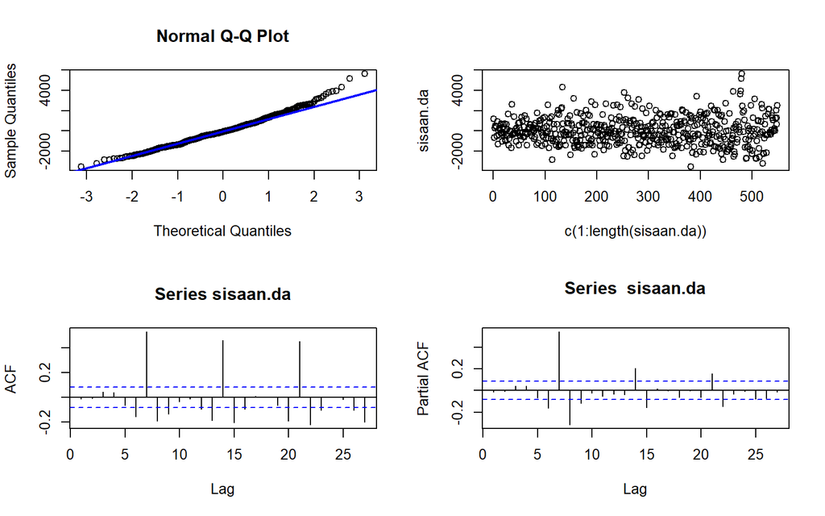

```r
#Eksplorasi
sisaan.da <- model1.da$residuals
par(mfrow=c(2,2))
qqnorm(sisaan.da)
qqline(sisaan.da, col = "blue", lwd = 2)
plot(c(1:length(sisaan.da)),sisaan.da)
acf(sisaan.da)
pacf(sisaan.da)
```

```r
par(mfrow = c(1,1))
```

Berdasarkan plot kuantil-kuantil normal, secara eksplorasi ditunjukkan diduga sisaannya tidak menyebar normal ditandai dengan titik-titik akhir yang tidak mengikuti garis yang telah dibuat.

Lebar pita sisaan yang cenderung tidak sama menandakan bahwa sisaan memiliki ragam yang heterogen.

### Uji Formal

#### Sisaan Menyebar Normal

```r
shapiro.test(sisaan.da)
```

```
##
##  Shapiro-Wilk normality test
##
## data:  sisaan.da
## W = 0.98653, p-value = 5.863e-05
```

```r
ks.test(sisaan.da,"pnorm")
```

```
##
##  Asymptotic one-sample Kolmogorov-Smirnov test
##
## data:  sisaan.da
## D = 0.52641, p-value < 2.2e-16
## alternative hypothesis: two-sided
```

$H_0$ : Sisaan menyebar normal

$H_1$ : Sisaan tidak menyebar normal

Berdasarkan uji KS tersebut, didapat *p-value* sebesar 2.2e-16 yang kurang dari taraf nyata 5% sehingga tolak $H_0$ dan menandakan bahwa sisaan tidak menyebar normal.

#### Sisaan saling bebas/tidak ada autokorelasi

```r
Box.test(sisaan.da, type = "Ljung")
```

```
##
##  Box-Ljung test
##
## data:  sisaan.da
## X-squared = 0.082533, df = 1, p-value = 0.7739
```

Selanjutnya akan dilakukan uji formal untuk kebebasan sisaan menggunakan uji Ljung-Box. Hipotesis yang digunakan adalah sebagai berikut.

$H_0$ : Sisaan saling bebas

$H_1$ : Sisaan tidak tidak saling bebas

Berdasarkan uji Ljung-Box tersebut, didapat *p-value* sebesar 0.7739 yang lebih besar dari taraf nyata 5% sehingga tak tolak $H_0$ dan menjelaskan sisaannya saling bebas.

#### Sisaan Homogen

```r
Box.test((sisaan.da)^2, type = "Ljung")
```

```
##
##  Box-Ljung test
##
## data:  (sisaan.da)^2
## X-squared = 61.35, df = 1, p-value = 4.774e-15
```

$H_0$ : Ragam sisaan homogen

$H_1$ : Ragam sisaan tidak homogen

#### Nilai tengah sisaan sama dengan nol

```r
t.test(sisaan.da, mu = 0, conf.level = 0.95)
```

```
##
##  One Sample t-test
##
## data:  sisaan.da
## t = 0.021033, df = 548, p-value = 0.9832
## alternative hypothesis: true mean is not equal to 0
## 95 percent confidence interval:
##  -111.2816  113.6904
## sample estimates:
## mean of x
##  1.204432
```

$H_0$ : nilai tengah sisaan sama dengan 0

$H_1$ : nilai tengah sisaan tidak sama dengan 0

### Kesimpulan Analsis Sisaan

Setelah dilakukan uji formal pada parameter model ARIMA (0,1,1) didapat bahwa semua uji lolos tetapi uji normalitas dan uji homogenitas tidak terpenuhi.

### Overfitting

Menggunakan ARIMA (0,1,1) dilakukan overfitting agar melihat apakah model yang didapat sudah bisa dilanjutkan ke proses analisis atau tidak.

```r
model1a.da=Arima(train.diff, order=c(0,0,2),method="ML")
summary(model1a.da)
```

```
## Series: train.diff
## ARIMA(0,0,2) with non-zero mean
##
## Coefficients:
##           ma1     ma2     mean
##       -0.5871  0.0218  36.0687
## s.e.   0.0438  0.0441  24.9270
##
## sigma^2 = 1806118:  log likelihood = -4732.33
## AIC=9472.66   AICc=9472.73   BIC=9489.89
##
## Training set error measures:
##                    ME     RMSE      MAE      MPE     MAPE      MASE
## Training set 1.181365 1340.242 1041.334 61.85766 178.9993 0.5106741
##                      ACF1
## Training set 0.0002728129
```

```r
lmtest::coeftest(model1a.da)
```

```
##
## z test of coefficients:
##
##            Estimate Std. Error  z value Pr(>|z|)
## ma1       -0.587052   0.043829 -13.3941   <2e-16 ***
## ma2        0.021800   0.044085   0.4945   0.6210
## intercept 36.068671  24.926980   1.4470   0.1479
## ---
## Signif. codes:  0 '***' 0.001 '**' 0.01 '*' 0.05 '.' 0.1 ' ' 1
```

```r
model1b.da=Arima(train.diff, order=c(1,0,1),method="ML")
summary(model1b.da)
```

```
## Series: train.diff
## ARIMA(1,0,1) with non-zero mean
##
## Coefficients:
##           ar1      ma1     mean
##       -0.0330  -0.5523  36.0643
## s.e.   0.0716   0.0587  24.8515
##
## sigma^2 = 1806223:  log likelihood = -4732.35
## AIC=9472.69   AICc=9472.77   BIC=9489.92
##
## Training set error measures:
##                    ME     RMSE      MAE      MPE     MAPE      MASE
## Training set 1.156321 1340.281 1041.145 61.77086 178.8072 0.5105811
##                      ACF1
## Training set -0.001386892
```

```r
lmtest::coeftest(model1b.da)
```

```
##
## z test of coefficients:
##
##            Estimate Std. Error z value Pr(>|z|)
## ar1       -0.033013   0.071552 -0.4614   0.6445
## ma1       -0.552282   0.058715 -9.4062   <2e-16 ***
## intercept 36.064301  24.851468  1.4512   0.1467
## ---
## Signif. codes:  0 '***' 0.001 '**' 0.01 '*' 0.05 '.' 0.1 ' ' 1
```

Setelah melakukan overfittin didapat bahwa model awal memiliki parameter yang signifikan dibandingkan dengan model yang lain.

## Peramalan

Peramalan dilakukan sesuai banyaknya data uji test agar dapat dicek nilai kebaikan forecastingnya.

```r
ramalan.da <- forecast::forecast(model1.da, h = 181)
ramalan.da
```

```
##     Point Forecast    Lo 80     Hi 80     Lo 95    Hi 95
## 551    -1406.39778 -3127.51  314.7143 -4038.612 1225.816
## 552       35.96799 -1948.28 2020.2160 -2998.678 3070.613
## 553       35.96799 -1948.28 2020.2160 -2998.678 3070.613
## 554       35.96799 -1948.28 2020.2160 -2998.678 3070.613
## 555       35.96799 -1948.28 2020.2160 -2998.678 3070.613
## 556       35.96799 -1948.28 2020.2160 -2998.678 3070.613
## 557       35.96799 -1948.28 2020.2160 -2998.678 3070.613
## 558       35.96799 -1948.28 2020.2160 -2998.678 3070.613
## 559       35.96799 -1948.28 2020.2160 -2998.678 3070.613
## 560       35.96799 -1948.28 2020.2160 -2998.678 3070.613
## 561       35.96799 -1948.28 2020.2160 -2998.678 3070.613
## 562       35.96799 -1948.28 2020.2160 -2998.678 3070.613
## 563       35.96799 -1948.28 2020.2160 -2998.678 3070.613
## 564       35.96799 -1948.28 2020.2160 -2998.678 3070.613
```

[output cut: 167 more lines]

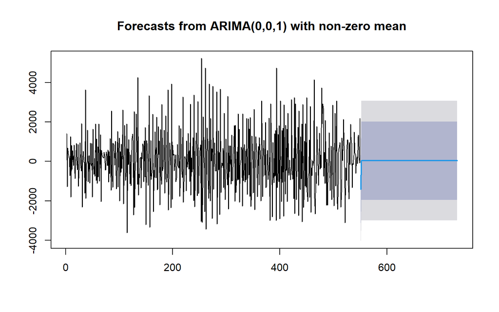

```r
data.ramalan.da <- ramalan.da$mean
plot(ramalan.da)
```

Selanjutnya, dapat dicari nilai akurasi antara hasil ramalan dengan data uji sebagai berikut.

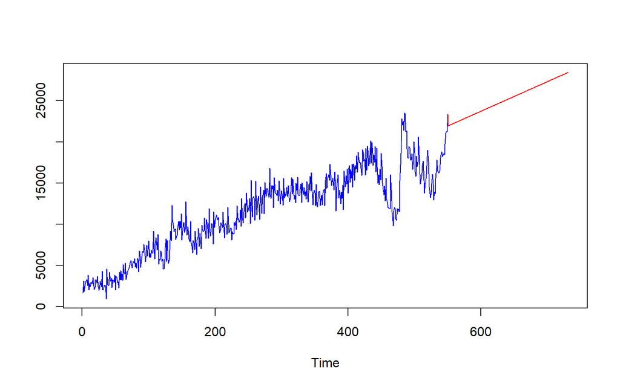

```r
pt_1 <- TrainP[550]
hasil.forc.Diff <- data.ramalan.da
hasil <- diffinv(hasil.forc.Diff, differences = 1) + pt_1
ts.plot(TrainP, hasil, col = c("blue", "red"))
```

Setelah melakukan peramalan didapat hasil ramalan untuk data diatas, agar melihat forecastingnya yang bagus atau tidak perlu melihat tingkat error pada forecastingnya dengan melihat nilai MAPE.

```r
perbandingan.da<-matrix(data=c(head(TestP, n=181), hasil[-1]),
                     nrow = 181, ncol = 2)
colnames(perbandingan.da)<-c("Aktual","Hasil Forecast")
perbandingan.da
```

```
##          Aktual Hasil Forecast
##   [1,] 20925.00       21959.60
##   [2,] 22244.00       21995.57
##   [3,] 21412.00       22031.54
##   [4,] 24937.00       22067.51
##   [5,] 24217.00       22103.47
##   [6,] 24168.00       22139.44
##   [7,] 19601.00       22175.41
##   [8,] 22545.00       22211.38
##   [9,] 23272.00       22247.35
##  [10,] 22262.00       22283.31
##  [11,] 22032.00       22319.28
##  [12,] 21660.00       22355.25
##  [13,] 21637.00       22391.22
##  [14,] 20870.00       22427.19
```

[output cut: 167 more lines]

```r
accuracy(ts(hasil[-1]), head(TestP, n=181))
```

```
##                 ME    RMSE      MAE       MPE     MAPE      ACF1 Theil's U
## Test set -5490.319 6062.14 5585.549 -28.91477 29.30845 0.7873102  3.917911
```

Didapat Hasil MAPE dari ARIMA(0,1,1) adalah 29.30845, hasil ini belum terbaik karna belum ada penanganan ketidakhomogenan ragam. Maka dilakukan ARIMA-Garch

# ARIMA-Garch

```r
for (i in 1:15) {
  ArchTest <- ArchTest(model1.da$residuals, lags=i, demean=TRUE)
  cat("P Value LM Test lag ke", i,"adalah" , ArchTest$p.value, "\n") }
```

```
## P Value LM Test lag ke 1 adalah 5.205314e-15
## P Value LM Test lag ke 2 adalah 3.815826e-15
## P Value LM Test lag ke 3 adalah 1.078568e-14
## P Value LM Test lag ke 4 adalah 4.848907e-14
## P Value LM Test lag ke 5 adalah 2.452383e-13
## P Value LM Test lag ke 6 adalah 4.836684e-13
## P Value LM Test lag ke 7 adalah 2.347962e-15
## P Value LM Test lag ke 8 adalah 3.815836e-15
## P Value LM Test lag ke 9 adalah 1.38478e-14
## P Value LM Test lag ke 10 adalah 4.736225e-14
## P Value LM Test lag ke 11 adalah 1.628788e-13
## P Value LM Test lag ke 12 adalah 2.685598e-13
## P Value LM Test lag ke 13 adalah 8.14808e-13
## P Value LM Test lag ke 14 adalah 3.950135e-15
## P Value LM Test lag ke 15 adalah 6.211203e-15
```

## Garch(0,1)

```r
modelgabung<-ugarchspec(variance.model = list(model = "sGARCH", garchOrder = c(0,1)),
                  mean.model = list(armaOrder = c(0,1), include.mean = TRUE),
                  distribution.model = "std")

m.01<-ugarchfit(spec=modelgabung,data=train.diff, out.sample = 181)
m.01
```

```
##
## *---------------------------------*
## *          GARCH Model Fit        *
## *---------------------------------*
##
## Conditional Variance Dynamics
## -----------------------------------
## GARCH Model  : sGARCH(0,1)
## Mean Model   : ARFIMA(0,0,1)
## Distribution : std
##
## Optimal Parameters
## ------------------------------------
##         Estimate  Std. Error   t value Pr(>|t|)
## mu      27.56556   11.783237    2.3394 0.019315
## ma1     -0.79832    0.028572  -27.9407 0.000000
## omega 2235.63366  458.892061    4.8718 0.000001
## beta1    0.99892    0.000322 3101.6368 0.000000
## shape    9.27983    3.726028    2.4905 0.012755
##
## Robust Standard Errors:
##         Estimate  Std. Error   t value Pr(>|t|)
## mu      27.56556   11.070570    2.4900 0.012775
## ma1     -0.79832    0.031037  -25.7215 0.000000
## omega 2235.63366  489.257460    4.5694 0.000005
## beta1    0.99892    0.000266 3758.3478 0.000000
## shape    9.27983    3.112383    2.9816 0.002868
##
## LogLikelihood : -3102.369
##
## Information Criteria
## ------------------------------------
##
## Akaike       16.888
## Bayes        16.941
## Shibata      16.888
## Hannan-Quinn 16.909
##
## Weighted Ljung-Box Test on Standardized Residuals
## ------------------------------------
```

[output cut: 40 more lines]

```
## Negative Sign Bias  2.4514 0.014699  **
## Positive Sign Bias  0.7154 0.474802
## Joint Effect       11.4453 0.009546 ***
##
##
## Adjusted Pearson Goodness-of-Fit Test:
## ------------------------------------
##   group statistic p-value(g-1)
## 1    20     12.76       0.8506
## 2    30     17.11       0.9605
## 3    40     28.96       0.8801
## 4    50     31.73       0.9736
##
##
## Elapsed time : 0.1629901
```

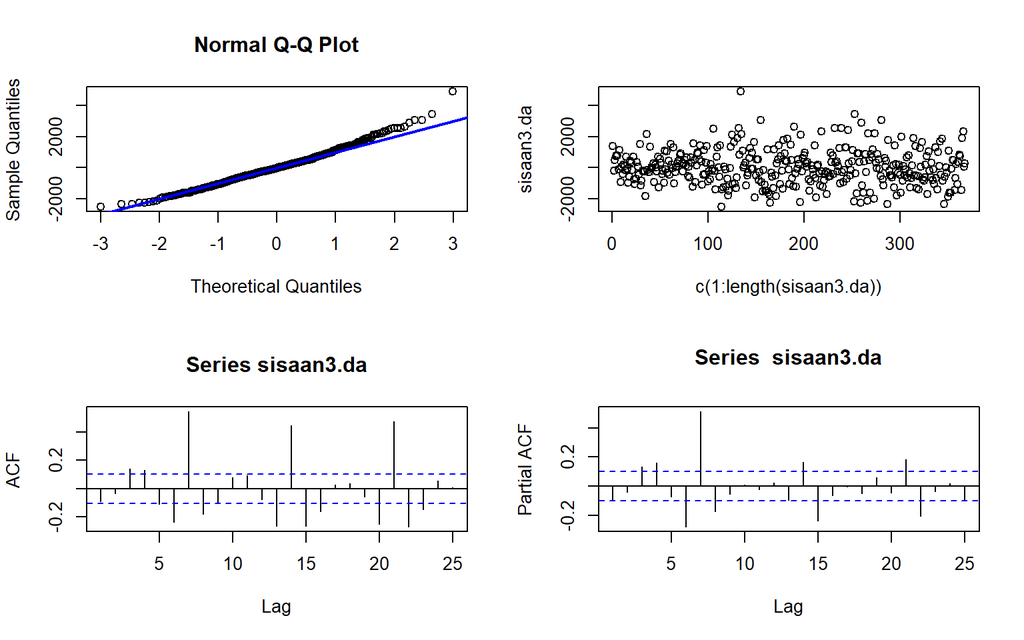

```r
#Eksplorasi
sisaan3.da <- residuals(m.01)
par(mfrow=c(2,2))
qqnorm(sisaan3.da)
qqline(sisaan3.da, col = "blue", lwd = 2)
plot(c(1:length(sisaan3.da)),sisaan3.da)
acf(sisaan3.da)
pacf(sisaan3.da)
```

```r
ks.test(sisaan3.da,"pnorm")
```

```
##
##  Asymptotic one-sample Kolmogorov-Smirnov test
##
## data:  sisaan3.da
## D = 1, p-value < 2.2e-16
## alternative hypothesis: two-sided
```

Menggunakan Uji KS, model di atas belum lolos uji normalitas

```r
#Autokol
Box.test(sisaan3.da, type = "Ljung")
```

```
##
##  Box-Ljung test
##
## data:  sisaan3.da
## X-squared = 3.0113, df = 1, p-value = 0.08269
```

```r
#Homogen
Box.test((sisaan3.da)^2, type = "Ljung")
```

```
##
##  Box-Ljung test
##
## data:  (sisaan3.da)^2
## X-squared = 3.1934, df = 1, p-value = 0.07394
```

**Setelah menggunakan penanganan GARCH(0,1), sisaan menjadi homogen**

```r
#Nilai Tengah
t.test(c(sisaan3.da), mu = 0, conf.level = 0.95)
```

```
##
##  One Sample t-test
##
## data:  c(sisaan3.da)
## t = 0.59732, df = 367, p-value = 0.5507
## alternative hypothesis: true mean is not equal to 0
## 95 percent confidence interval:
##  -79.92831 149.67034
## sample estimates:
## mean of x
##  34.87101
```

Berdasarkan uji-ttersebut, didapat *p-value* sebesar 0.5507 yang lebih besar dari taraf nyata 5% sehingga tak tolak $H_0$ dan menandakan bahwa nilai tengah sisaan sama dengan nol.

```r
forc <- ugarchforecast(m.01, data = train.diff, n.ahead = 181)
ramalan <- forc@forecast$seriesFor[,1]
pt_1 <- TrainP[550] #nilai akhir data latih
hasil.forc <- diffinv(ramalan, differences = 1) + pt_1
Hasil.forc <- hasil.forc[-1]

perbandingan <- data.frame("Aktual"= TestP,
                           "Ramalan" = Hasil.forc)
perbandingan
```

```
##       Aktual  Ramalan
## 1   20925.00 23191.76
## 2   22244.00 23219.33
## 3   21412.00 23246.89
## 4   24937.00 23274.46
## 5   24217.00 23302.02
## 6   24168.00 23329.59
## 7   19601.00 23357.16
## 8   22545.00 23384.72
## 9   23272.00 23412.29
## 10  22262.00 23439.85
## 11  22032.00 23467.42
## 12  21660.00 23494.98
## 13  21637.00 23522.55
## 14  20870.00 23550.11
```

[output cut: 167 more lines]

```r
library(forecast)
accuracy(ts(Hasil.forc), head(TestP, n=181))
```

```
##                ME     RMSE      MAE       MPE     MAPE      ACF1 Theil's U
## Test set -5966.26 6391.783 6004.005 -31.36906 31.52281 0.7330682  4.140655
```

Didapat nilai MAPEnya lebih tinggi yaitu 31.52281 yang dibandingkan dengan pemodelan ARIMA-nya saja yaitu senilai 29.30845

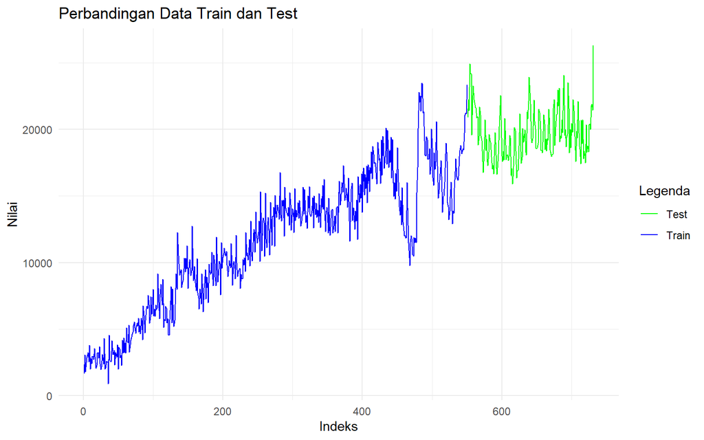

```r
# Menggabungkan data train dan test
data_gabungan_train_test <- data.frame(
  Indeks = seq_len(length(c(TrainP, TestP))),  # Indeks untuk x-axis
  Train = c(TrainP, rep(NA, length(TestP))),    # Data Train
  Test = c(rep(NA, length(TrainP)), TestP)       # Data Test
)

# Memuat library ggplot2
library(ggplot2)

# Membuat plot untuk Data Train dan Data Test
plot_train_test <- ggplot(data_gabungan_train_test, aes(x = Indeks)) +
  geom_line(aes(y = Train, color = "Train")) +               # Garis untuk data train
  geom_line(aes(y = Test, color = "Test")) +                 # Garis untuk data test
  labs(title = "Perbandingan Data Train dan Test",
       x = "Indeks",
       y = "Nilai") +
  scale_color_manual(name = "Legenda",
                     values = c("Train" = "blue", "Test" = "green")) +
  theme_minimal()

# Menampilkan plot
print(plot_train_test)
```

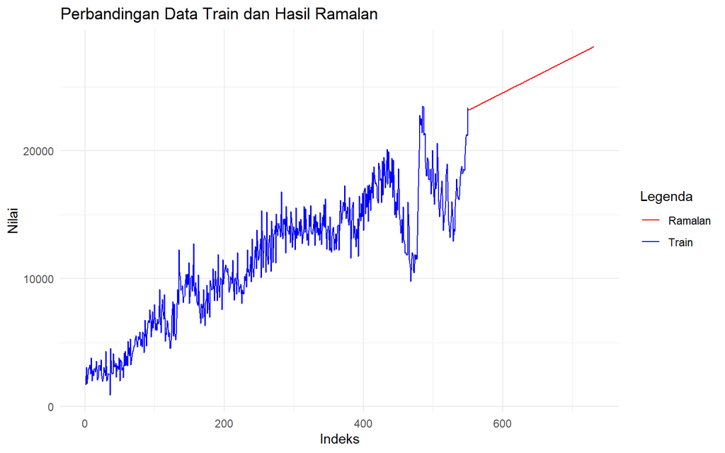

```r
# Menggabungkan data train dan hasil ramalan
data_gabungan_train_ramalan <- data.frame(
  Indeks = seq_len(length(c(TrainP, Hasil.forc))),  # Indeks untuk x-axis
  Nilai = c(TrainP, Hasil.forc),                     # Nilai untuk data Train dan Ramalan
  Tipe = c(rep("Train", length(TrainP)), rep("Ramalan", length(Hasil.forc)))  # Kategori untuk Train dan Ramalan
)

# Membuat plot untuk Data Train dan Hasil Ramalan
plot_train_ramalan <- ggplot(data_gabungan_train_ramalan, aes(x = Indeks, y = Nilai, color = Tipe)) +
  geom_line() +                                         # Garis untuk data train dan ramalan
  labs(title = "Perbandingan Data Train dan Hasil Ramalan",
       x = "Indeks",
       y = "Nilai") +
  scale_color_manual(name = "Legenda",
                     values = c("Train" = "blue", "Ramalan" = "red")) +
  theme_minimal()

# Menampilkan plot
print(plot_train_ramalan)
```

## Garch(1,1)

```r
modelgabung<-ugarchspec(variance.model = list(model = "sGARCH", garchOrder = c(1,1)),
                  mean.model = list(armaOrder = c(1,1), include.mean = TRUE),
                  distribution.model = "std")

m.11<-ugarchfit(spec=modelgabung,data=train.diff, out.sample = 181)
m.11
```

```
##
## *---------------------------------*
## *          GARCH Model Fit        *
## *---------------------------------*
##
## Conditional Variance Dynamics
## -----------------------------------
## GARCH Model  : sGARCH(1,1)
## Mean Model   : ARFIMA(1,0,1)
## Distribution : std
##
## Optimal Parameters
## ------------------------------------
##           Estimate  Std. Error   t value Pr(>|t|)
## mu       36.465790  4.0737e+01  0.895151  0.37071
## ar1      -0.177077  2.7922e-01 -0.634186  0.52596
## ma1      -0.750861  9.2671e-02 -8.102478  0.00000
## omega  2235.099640  1.1730e+04  0.190544  0.84888
## alpha1    0.057099  7.6417e-02  0.747203  0.45494
## beta1     0.941901  8.0682e-02 11.674190  0.00000
## shape    96.939631  6.4299e+03  0.015076  0.98797
##
## Robust Standard Errors:
##           Estimate  Std. Error   t value Pr(>|t|)
## mu       36.465790  5.8987e+02  0.061820  0.95071
## ar1      -0.177077  4.1137e+00 -0.043046  0.96566
## ma1      -0.750861  1.2591e+00 -0.596347  0.55094
## omega  2235.099640  1.2429e+05  0.017982  0.98565
## alpha1    0.057099  1.1172e+00  0.051109  0.95924
## beta1     0.941901  1.1849e+00  0.794908  0.42667
## shape    96.939631  9.7006e+04  0.000999  0.99920
##
## LogLikelihood : -3095.071
##
## Information Criteria
## ------------------------------------
##
## Akaike       16.859
## Bayes        16.933
## Shibata      16.858
```

[output cut: 46 more lines]

```
## Negative Sign Bias  0.3177 0.7509
## Positive Sign Bias  0.5278 0.5980
## Joint Effect        4.7251 0.1931
##
##
## Adjusted Pearson Goodness-of-Fit Test:
## ------------------------------------
##   group statistic p-value(g-1)
## 1    20     15.04       0.7198
## 2    30     23.63       0.7469
## 3    40     34.83       0.6607
## 4    50     37.16       0.8924
##
##
## Elapsed time : 0.2486391
```

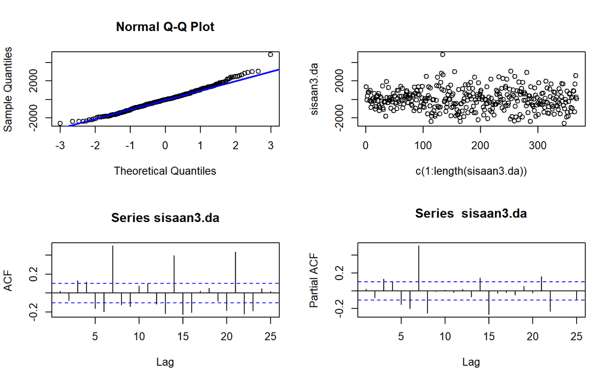

```r
#Eksplorasi
sisaan3.da <- residuals(m.11)
par(mfrow=c(2,2))
qqnorm(sisaan3.da)
qqline(sisaan3.da, col = "blue", lwd = 2)
plot(c(1:length(sisaan3.da)),sisaan3.da)
acf(sisaan3.da)
pacf(sisaan3.da)
```

```r
ks.test(sisaan3.da,"pnorm")
```

```
##
##  Asymptotic one-sample Kolmogorov-Smirnov test
##
## data:  sisaan3.da
## D = 1, p-value < 2.2e-16
## alternative hypothesis: two-sided
```

Menggunakan Uji KS, model di atas belum lolos uji normalitas

```r
#Autokol
Box.test(sisaan3.da, type = "Ljung")
```

```
##
##  Box-Ljung test
##
## data:  sisaan3.da
## X-squared = 0.19182, df = 1, p-value = 0.6614
```

```r
#Homogen
Box.test((sisaan3.da)^2, type = "Ljung")  #tak tolak H0 > sisaan homogen
```

```
##
##  Box-Ljung test
##
## data:  (sisaan3.da)^2
## X-squared = 4.7621, df = 1, p-value = 0.02909
```

Setelah menggunakan penanganan GARCH(1,1), sisaan tetap tidak homogen

```r
#Nilai Tengah
t.test(c(sisaan3.da), mu = 0, conf.level = 0.95)
```

```
##
##  One Sample t-test
##
## data:  c(sisaan3.da)
## t = -0.12475, df = 367, p-value = 0.9008
## alternative hypothesis: true mean is not equal to 0
## 95 percent confidence interval:
##  -121.3761  106.8949
## sample estimates:
## mean of x
## -7.240624
```

Berdasarkan uji-ttersebut, didapat *p-value* sebesar 0.9008 yang lebih besar dari taraf nyata 5% sehingga tak tolak $H_0$ dan menandakan bahwa nilai tengah sisaan sama dengan nol.

```r
forc <- ugarchforecast(m.11, data = train.diff, n.ahead = 181)
ramalan <- forc@forecast$seriesFor[,1]
pt_1 <- TrainP[550] #nilai akhir data latih
hasil.forc <- diffinv(ramalan, differences = 1) + pt_1
Hasil.forc <- hasil.forc[-1]

perbandingan <- data.frame("Aktual"= TestP,
                           "Ramalan" = Hasil.forc)
perbandingan
```

```
##       Aktual  Ramalan
## 1   20925.00 23309.99
## 2   22244.00 23362.83
## 3   21412.00 23396.40
## 4   24937.00 23433.38
## 5   24217.00 23469.75
## 6   24168.00 23506.23
## 7   19601.00 23542.70
## 8   22545.00 23579.16
## 9   23272.00 23615.63
## 10  22262.00 23652.09
## 11  22032.00 23688.56
## 12  21660.00 23725.02
## 13  21637.00 23761.49
## 14  20870.00 23797.96
```

[output cut: 167 more lines]

```r
library(forecast)
accuracy(ts(Hasil.forc), head(TestP, n=181))
```

```
##                 ME    RMSE      MAE       MPE     MAPE      ACF1 Theil's U
## Test set -6899.354 7368.82 6931.538 -36.12709 36.25806 0.7901743  4.754472
```

Sama halnya dengan ARIMA-Garch(0,1) Didapati nilai MAPEnya lebih tinggi yaitu 36.25806 yang dibandingkan dengan pemodelan ARIMA-nya saja yaitu senilai 29.30845

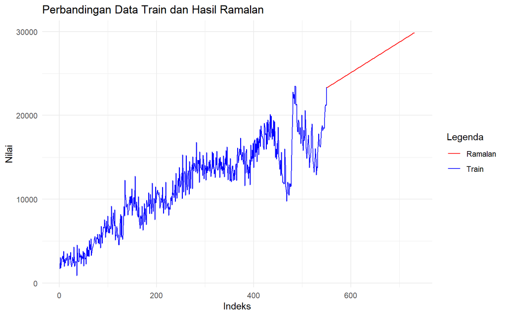

```r
# Menggabungkan data train dan hasil ramalan
data_gabungan_train_ramalan <- data.frame(
  Indeks = seq_len(length(c(TrainP, Hasil.forc))),  # Indeks untuk x-axis
  Nilai = c(TrainP, Hasil.forc),                     # Nilai untuk data Train dan Ramalan
  Tipe = c(rep("Train", length(TrainP)), rep("Ramalan", length(Hasil.forc)))  # Kategori untuk Train dan Ramalan
)

# Membuat plot untuk Data Train dan Hasil Ramalan
plot_train_ramalan <- ggplot(data_gabungan_train_ramalan, aes(x = Indeks, y = Nilai, color = Tipe)) +
  geom_line() +                                         # Garis untuk data train dan ramalan
  labs(title = "Perbandingan Data Train dan Hasil Ramalan",
       x = "Indeks",
       y = "Nilai") +
  scale_color_manual(name = "Legenda",
                     values = c("Train" = "blue", "Ramalan" = "red")) +
  theme_minimal()

# Menampilkan plot
print(plot_train_ramalan)
```

# KESIMPULAN MODEL TERBAIK

Model terbaik hingga saat ini yaitu menggunakan ARIMA(0,1,1)-GARCH(0,1), dimana sudah memenuhi asumsi kehomogenan dengan MAPE sebesar 31.52281